# Identification of Alternative Splicing and polyadenylation in bulk RNA-seq data

Ying Zheng

24/02/2021

# Introduction

NOTE: The context of this R markdown file includes all the R code requied for the analysis of differential polyadenylation site (PAS) usage analysis of 3P-Seq data. Refer to the PART 2- 3P-Seq analysis of the Protocol section.

# 1. Data downloading and pre-processing

NOTE: The data downloading and pre-processing steps were performed on terminal rather than R console. Refer to the supplementary bash file “Data_PreProcessing.3PSeq.sh” for the step by step procedure.

## 1.1 Data downloading

The raw data used in this analysis were downloaded from Sequence Read Archive [SRA] using the `prefetch` command from SRA toolkit. Given the SRA Accession Ids (1553129 to 1553136) in sequence, the SRA files were downloaded in parallel using GNU parallel. Then fastq files were extracted directly from these SRA files using `fastq-dump` from SRA toolkit.

```r
#Creat project directory to store raw data
PROJ_DIR=AS_analysis/
mkdir $PROJ_DIR
cd $PROJ_DIR

RAW_DATA=raw_data
mkdir -p $RAW_DATA
cd $RAW_DATA
# Download SRA files using accession numbers
seq 1553129 1553136 | parallel prefetch SRR{}

# Convert SRA to fastq
parallel -j 3 fastq-dump --gzip --skip-technical --read-filter pass --dumpbase --split-e --clip --origfmt {} ::: SRR1553129/SRR1553129.sra SRR1553130/SRR1553130.sra SRR1553131/SRR1553131.sra SRR1553132/SRR1553132.sra SRR1553133/SRR1553133.sra SRR1553134/SRR1553134.sra SRR1553135/SRR1553135.sra SRR1553136/SRR1553136.sra

# Unzip the fastq.gz data to gain fastq files
parallel “gunzip {}” :::$RAW_DATA/*.fastq.gz

cd ..
```

## 1.2 Reference genome and annotations downloading

```r
# Download the bowtie Index of mm10
wget https://genome-idx.s3.amazonaws.com/bt/mm10.zip
unzip mm10.zip

# Download the mm10.chrom.sizes
wget https://hgdownload-test.gi.ucsc.edu/goldenPath/mm10/bigZips/mm10.chrom.sizes
```

## 1.3 Data pre-processing, read alignment and genome coverage visualisation

As the length of the reads gained in this set of PolyA-Seq data was short (~35 bases), Illumina adapter trimming was performed with `cutadapt` to remove the influence of the adapter sequence on analysis results. Meanwhile, according to the description of library preparation steps in the original article, the sequencing of this set of data was performed on the antisense strand. Therefore, after adapter trimming, the reads saved in fasq files were reverse complemented with the help of FASTX toolkit to obtain the sense strand sequence before genome alignment. The mouse genome alignment of the data was accomplished using bowtie aligner, and the success rate of the alignment were calculated and visualized directly with the generation of mapped SAM files. Each SAM file was converted to BAM files using `samtools` and split into two BigWig files based on the strand for the genome coverage visualization at the pA cleavage sites.

```r
# Create multiple directories to store data generated in different pre-processing steps
TRIM_DIR=adapter.trimming.results
mkdir $TRIM_DIR

TRIMRC_DIR=trimmed.rc.data
mkdir $TRIMRC_DIR

SAM_DIR=samfiles
mkdir $SAM_DIR

BAM_DIR=bamfiles
mkdir $BAM_DIR

BDG_DIR=bedgraphfiles
mkdir $BDG_DIR

BW_DIR=BigWigfiles
mkdir $BW_DIR

CM_DIR=compute.matrix.results
mkdir $CM_DIR

HM_DIR=plotHeatmap.results
mkdir $HM_DIR

for fq in $RAW_DATA/*.fastq
do
OUTPUT=$(basename ${fq}| sed ’s/_pass.fastq//g’);

# Apply adapter trimming
cutadapt -a "AGATCGGAAGAGC"  -m 15 -n 3 ${fq} | fastx_reverse_complement -i > $TRIM_DIR\/${OUTPUT}_trimmed.fastq

# Get reverse complemented sequence
fastx_reverse_complement -i $TRIM_DIR\/${OUTPUT}_trimmed.fastq -o $TRIMRC_DIR\/${OUTPUT}_trimmed_rc.fastq

# Perform genome alignment of reads using bowtie
bowtie -n 2 -k 100 --best --strata -p 10  -x mm10/genome  --un unmapped_out $TRIMRC_DIR\/${OUTPUT}_trimmed_rc.fastq -S > SAM_DIR\/${OUTPUT}.sam

# Convert sam files to bam files
samtools view -bS SAM_DIR\/${OUTPUT}.sam -o BAM_DIR\/${OUTPUT}.bam
samtools sort BAM_DIR\/${OUTPUT}.bam -o BAM_DIR\/${OUTPUT}.sorted.bam
samtools index BAM_DIR\/${OUTPUT}.sorted.bam

# Generate genomeCoverageBed files for the coverage visualisation to decide the flanking regions included in the annotation file
genome_f = mm10.chrom.sizes.txt
genomeCoverageBed -split -strand + -bga -ibam BAM_DIR\/${OUTPUT}.sorted.bam | sort -k 1,1 -k2,2n > BDG_DIR\/${OUTPUT}.bedgraph_fwd
genomeCoverageBed -split -strand - -bga -ibam BAM_DIR\/${OUTPUT}.sorted.bam | sort -k 1,1 -k2,2n > BDG_DIR\/${OUTPUT}.bedgraph_rev

# Generate bigwig files for the check in the genome browser/IGV
wigToBigWig BDG_DIR\/${OUTPUT}.bedgraph_fwd mm10.chrom.sizes.txt BDG_DIR\/${OUTPUT}.fwd.bw
wigToBigWig BDG_DIR\/${OUTPUT}.bedgraph_rev mm10.chrom.sizes.txt BDG_DIR\/${OUTPUT}.rev.bw

# Visualisation of the genome coverage at polyA sites
computeMatrix reference-point -S BDG_DIR\/${OUTPUT}.fwd.bw -R polyA_annotation.fwd.bed -a 200 -b 200 -o CM_DIR\/${OUTPUT}.fwd.ud200.gz --referencePoint center --sortRegions no
plotHeatmap -m  CM_DIR\/${OUTPUT}.fwd.ud200.gz -o HM_DIR\/${OUTPUT}.fwd.ud200.pdf

computeMatrix reference-point -S BDG_DIR\/${OUTPUT}.rev.bw -R polyA_annotation.fwd.bed -a 200 -b 200 -o CM_DIR\/${OUTPUT}.rev.ud200.gz --referencePoint center --sortRegions no
plotHeatmap -m CM_DIR\/${OUTPUT}.rev.ud200.gz -o HM_DIR\/${OUTPUT}.rev.ud200.pdf

done
```

# 2. Preparing pA sites annotations

The tsv file of pA site annotation “atlas.clusters.2.0.GRCm38.96.tsv” can be downloaded directly using the PolyASite 2.0 database from https://polyasite.unibas.ch. The processing of the pA site annotation file was preformed firstly in R console, and then in terminal using the Linux command-line described in supplementary file “Anno_Processing.3PSeq.sh”. Only the pA sites annotated as Terminal Exon (TE) or 1000 nt downstream of an annotated terminal exon (DS) were retained as 3’UTR pA sites for analysis.

## 2.1 Select the analysis-related information to generate the new annotation file

```r
# Load required libraries
library(magrittr)
library(dplyr)

# Load the unprocessed annotation file
anno <- read.delim("/Users/evelynzheng/3PSeq_files/atlas.clusters.2.0.GRCm38.96.tsv",
                   stringsAsFactors = FALSE, check.names = FALSE, header = TRUE) %>%
  dplyr::select(chrom, chromStart, chromEnd, name, score, strand, rep, annotation, gene_name, gene_id) %$%
  .[(.$annotation %in% "TE") | (.$annotation %in% "DS"), ]
# Select our intesrested pA sites annotated as Terminal Exon (TE), 1,000 nt DownStream of an annotated terminal exon (DS)
```

## 2.2 Modify the information formats in the new annotation file

NOTE: As the tools that we will use for pA site usage analysis were designed for differential exon usage and splicing analysis, the input unique feature IDs (namely unique pA site cluster IDs) are expected to be in the format of ‘group ID: feature ID’ (namely ‘gene ID: pA site cluster ID’), while the cluster IDs in both the annotation file and the count table are in the format of ‘group ID: feature ID: strand’. Therefore, for the convenience of downstream analysis and to avoid duplicates in the cluster IDs, we removed the last common is the original cluster IDs and replace the strand information `+` and `-` with letters `F` (Forward) and `R`(Reverse) individually using the R function below.

```r
anno$name <- anno$strand %>% replace(. %in% "+", "F") %>% # Replace the strand information '+' with 'F'
  replace(. %in% "-", "R") %>% # Replace the strand information '-' with 'R'
  paste0(anno$gene_name, ":", anno$rep, .) # Generate new unique pA site cluster IDs

anno$chrom <- paste0("chr", anno$chrom) # change the format of chromosome column for downstream analysis

# Replace coordinates of pA sites with their corresponding cleavage sites
anno$chromStart <-  anno$rep -1
anno$chromEnd <-  anno$rep
```

## 2.3 Apply the chromosome level filtering to the annotation file

```r
# Remove the unimportant chromosomes
anno %<>% {
  chrom.list <- paste0("chr", as.character(c(1:19, "X", "Y")))
  .[.$chrom %in% chrom.list, ]}
```

## 2.4 Generate annotation files for each strand

```r
# Generate annotation files for each strand for genomeCoverage plotting
anno %T>%
  {
    anno.fwd = .[.$strand %in% "+", ]
    write.table(anno.fwd, file = "polyA_annotation.fwd.bed", row.names = FALSE, col.names = FALSE, sep = "\t", quote = FALSE)
    } %>% {
    anno.rev <- .[.$strand %in% "-", ]
    write.table(anno.rev, file = "polyA_annotation.rev.bed", row.names = FALSE, col.names = FALSE, sep = "\t", quote = FALSE)
  }
```

## 2.5 Save the annotation file in bed format

```r
anno %>% write.table(file = "polyA_annotation.bed", row.names = FALSE, col.names = FALSE, sep = "\t", quote = FALSE)
```

## 2.6 Modify the coordinates of pA sites in terminal

NOTE: To obtain pA site peaks, we anchored at each pA cleavage site, and visualized the average read coverage on flanking regions around the cleavage sites as accomplished in the last step (1.3). The results showed that the peaks of the mapped reads were mainly dispersed within ~60 bp upstream of the cleavage sites (Refer to the supplementary figure “merge.heatmap.png”). Therefore, we extended the coordinates of pA sites from the annotation file to 60 bp upstream of their cleavage sites in the analysis of the PolyA-Seq data.

```r
# Download the mm10.chrom.sizes
wget https://hgdownload-test.gi.ucsc.edu/goldenPath/mm10/bigZips/mm10.chrom.sizes

# Change che added value based on the genomeCov results
bedtools slop -i polyA_annotation.bed -g mm10.chrom.sizes.txt -l 60 -r 0 -s > flanking60added.polyA_annotation.bed
```

NOTE: After the further processing in terminal, the final processed file used in downstream analysis was named as “flanking60added.polyA_annotation.bed”. Refer to the supplementary file “Anno_Processing.3PSeq.sh” for details.

# 3 Counting Reads

Then we will read all bam files obtained as input for `featureCounts()` from `Rsubread` package (Liao, Y., 2019) to acquire the raw counts of reads mapped to each annotated pA site. The count table was saved as a file for further differential polyadenylation site usage analysis using different tools.

## 3.1 Load required libraries

The following packages were used for this part of the analysis. Make sure to install the packages if they are not already installed.

```r
# Load required libraries
c("Rsubread","tibble") %>% lapply(library, character.only = TRUE) %>% invisible
```

## 3.2 Prepare the processed pA sites annotation file for featureCounts

We selected eight typical elements useful for differential polyadenylation site usage analysis, including unique pA site cluster ID, chromosome name, start and end positions of the pA site cluster, strand on which the cluster is encoded, the overlapping gene ensembles and their corresponding gene symbols, and the representative pA site of the cluster.

```r
anno <- read.table(file = "/Users/evelynzheng/3PSeq_files/flanking60added.polyA_annotation.bed", stringsAsFactors=FALSE, check.names=FALSE, header=FALSE, sep = "")
colnames(anno) <- c("Chr", "Start", "End", "GeneID", "Score", "Strand", "repID", "Anno", "Symbol", "Ensembl")
anno <- dplyr::select(anno, GeneID, Chr, Start, End, Strand, Ensembl, Symbol, repID)
```

## 3.3 Apply featureCounts to acquire the raw counts

Then we will read all bam files obtained as input for featureCounts to acquire the raw counts of reads mapped to each annotated pA site. The count table was saved as a file for further differential polyadenylation site usage analysis using different tools. NOTE: Before running this step, make sure you have the folder containing bam files in the current working directory.

```r
# As the running of featureCounts requires around 25 G memory, this step was running on server and the result was saved as "countData.RData" and loaded in the next R session.
countData <- dir("bamfiles", pattern="sorted.bam$", full.names = TRUE) %>%  # Read all bam files as input for featureCounts
featureCounts(annot.ext = anno, isGTFAnnotationFile = FALSE, minMQS = 0, useMetaFeatures = TRUE,
              allowMultiOverlap = TRUE, largestOverlap = TRUE, strandSpecific = 1,
              countMultiMappingReads = TRUE, primaryOnly = TRUE, isPairedEnd = FALSE, nthreads = 12) %T>%
save(file = "APA_countData.RData")
```

## 3.4 Apply non-sepecific filtering of countData

Filtering can significantly improve the statistical robustness in differential pA site usage tests. First, we removed those genes with only one pA site, on which differentially pA site usage cannot be defined. Second, we apply non-specific filtering based on coverage: counts are filtered by cpm (counts per million) less than 1 in x out of n samples, where x is the minimum number of replicates in any condition. n = 8 and x = 2 for this example data.

```r
load(file = "/Users/evelynzheng/3PSeq_files/APA_countData.RData") # Avoid this step if it is already loaded

countData <-  countData$counts %>% as.data.frame %>% .[rowSums(edgeR::cpm(.) > 1) >= 2, ]
anno %<>% .[.$GeneID %in% rownames(countData), ]

# Remove genes with only 1 site and  NA in geneIDs
dnsites <- anno %>% group_by(Symbol) %>% summarise(nsites=n()) %>% filter(nsites > 1 & !is.na(Symbol))
anno %<>% filter(Symbol %in% dnsites$Symbol)
countData %<>% .[rownames(.) %in% anno$GeneID, ]
```

# 4 Differential polyadenylation sites usage analysis using DEXSeq and diffSplice pipelines

## 4.1 Using DEXSeq package

### 4.1.1 Load library and create a sample table to define the experimental design

```r
"DEXSeq" %>% lapply(library, character.only = TRUE) %>% invisible

sampleTable <- data.frame(row.names = c("WT_1","WT_2","DKO_1","DKO_2", "DKOsiRNA_1", "DKOsiRNA_2", "DKONTsiRNA_1", "DKONTsiRNA_2"),
                          condition = c(rep("WT", 2), rep("DKO", 2),  rep("KD", 2), rep("Ctrl", 2)),
                          libType = rep("single-end", 8))
```

NOTE: The row names should be consistent with the bam file names used by `featureCounts` to count the reads. sampleTable consists of details of each sample which includes- library-type and condition. This is required to define the contrasts or test group for detecting differential usage.

### 4.1.2 Prepare the pA sites information file

PA site information in form of GRanges object is required as an input to create DEXSeq object. Match the gene Ids with the read counts and extract their specific annotation present in the prepared annotation object to create PASinfo object.

```r
# Prepare the GRanges object for DEXSeqDataSet object construction
PASinfo <- GRanges(seqnames = anno$Chr,
                   ranges = IRanges(start = anno$Start, end = anno$End),
                   strand = Rle(anno$Strand))
mcols(PASinfo)$PASID <- anno$repID
mcols(PASinfo)$GeneEns <- anno$Ensembl
mcols(PASinfo)$GeneID <- anno$Symbol

# Prepare the new feature IDs, replace the strand information with letters to match the current pA site clusterID
new.featureID <- anno$Strand %>% as.character %>% replace(. %in% "+", "F") %>% replace(. %in% "-", "R") %>% paste0(as.character(anno$repID), .)
```

NOTE: Be careful with the names of the columns of the processed annotation file. With different annotations, the headers can change and cause a problem while running this step.

### 4.1.3 Create the DEXSeq object

Use the read counts generated in step 3 and the PAS information obtained from the previous step to create the DEXSeq object. The sampleData takes a data frame input defining the samples (and their attributes- library type and condition), `design` uses sampleData to generate a design matrix for the differential testing. For feature information, pA site IDs and their corresponding gene are required.

```r
colnames(countData) <- rownames(sampleTable) # Rename the columns of countData using sample names in sampleTable
dxd <- DEXSeqDataSet(countData = countData,
                     sampleData = sampleTable,
                     design = ~ sample + exon + condition:exon,
                     featureID = new.featureID,
                     groupID = anno$Symbol,
                     featureRanges = PASinfo)
```

```
some variables in design formula are characters, converting to factors
```

NOTE: This step might take some time. Once the object is created, explore the columns for initial understanding of data.

```r
# Explore/Inspect the DEXSeq object
head(counts(dxd), 5)
```

```
                [,1] [,2] [,3] [,4] [,5] [,6] [,7] [,8] [,9] [,10] [,11] [,12] [,13] [,14] [,15] [,16]
Akap12:4359096F   74  110   21   29   53   37   40    3  492   671   203   201   992   316   412   206
Akap12:4359468F  492  671  203  201  992  316  412  206   74   110    21    29    53    37    40     3
Lats1:7716088F    46   82   41   25   11    6    9    9  283   416   320   257   108    41    42    29
Lats1:7716124F    85  108   82   66   13   13   23   11  244   390   279   216   106    34    28    27
Lats1:7716458F   198  308  238  191   95   28   19   18  131   190   123    91    24    19    32    20
```

```r
colData(dxd)
```

```
DataFrame with 16 rows and 4 columns
          sample condition     libType     exon
        <factor>  <factor> <character> <factor>
1     WT_1             WT   single-end     this
2     WT_2             WT   single-end     this
3     DKO_1            DKO  single-end     this
4     DKO_2            DKO  single-end     this
5     DKOsiRNA_1       KD   single-end     this
...          ...       ...         ...      ...
12  DKO_2             DKO   single-end   others
13  DKOsiRNA_1        KD    single-end   others
14  DKOsiRNA_2        KD    single-end   others
15  DKONTsiRNA_1      Ctrl  single-end   others
16  DKONTsiRNA_2      Ctrl  single-end   others
```

```r
split(seq_len(ncol(dxd)), colData(dxd)$exon)
```

```
$others
[1]  9 10 11 12 13 14 15 16

$this
[1] 1 2 3 4 5 6 7 8
```

```r
#head(featureCounts(dxd), 5)
head(rowRanges(dxd), 3)
```

```
GRanges object with 3 ranges and 7 metadata columns:
                  seqnames          ranges strand |     PASID            GeneEns      GeneID   featureID     groupID
                     <Rle>       <IRanges>  <Rle> | <integer>        <character> <character> <character> <character>
  Akap12:4359096F    chr10 4359035-4359096      + |   4359096 ENSMUSG00000038587      Akap12    4359096F      Akap12
  Akap12:4359468F    chr10 4359407-4359468      + |   4359468 ENSMUSG00000038587      Akap12    4359468F      Akap12
   Lats1:7716088F    chr10 7716027-7716088      + |   7716088 ENSMUSG00000040021       Lats1    7716088F       Lats1
                  exonBaseMean exonBaseVar
                     <numeric>   <numeric>
  Akap12:4359096F       45.875    1115.554
  Akap12:4359468F      436.625   77840.554
   Lats1:7716088F       28.625     701.411
  -------
  seqinfo: 21 sequences from an unspecified genome; no seqlengths
```

```r
sampleAnnotation(dxd)
```

```
DataFrame with 8 rows and 3 columns
        sample condition     libType
      <factor>  <factor> <character>
1 WT_1              WT    single-end
2 WT_2              WT    single-end
3 DKO_1             DKO   single-end
4 DKO_2             DKO   single-end
5 DKOsiRNA_1        KD    single-end
6 DKOsiRNA_2        KD    single-end
7 DKONTsiRNA_1      Ctrl  single-end
8 DKONTsiRNA_2      Ctrl  single-end
```

### 4.1.4 Define the contrast pairs in countData

In DEXSeq pipeline, the log2 fold change data is generated in contrast pairs. If not defined, the conditions saved in DEXSeq object will be transferred to alphabetical order-based factors, and the contrast pairs will be composed of 1) one of the three conditions with high levels, and 2) the condition with the lowest level. Therefore, we can define the contrast parirs through defining the levels of conditions in DEXSeq object.

```r
dxd$condition <- factor(dxd$condition, levels = c("DKO", "WT", "Ctrl", "KD"))
# The contrast pairs will be "WT-DKO", "Ctrl-DKO", "Ctrl-DKO", "KD-DKO"
```

### 4.1.5 Normalization and Dispersion Estimation

Next, we perform the normalisation and estimate the variability of the data using the following commands.

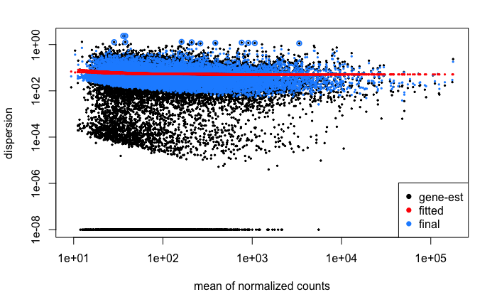

```r
dxd %<>% estimateSizeFactors %>% estimateDispersions %T>% plotDispEsts # Visualization of the dispersion esitimation result
```

### 4.1.6 Differential pA site usage testing

After the estimation of variation, we test for differential exon usage for each gene and generate the results. The results are calculated at FDR 10%.

```r
dxd %<>% testForDEU %>% estimateExonFoldChanges(fitExpToVar = "condition") #Estimate fold changes
dxr <- DEXSeqResults(dxd)
dxr
```

```
LRT p-value: full vs reduced

DataFrame with 13283 rows and 16 columns
                    groupID   featureID exonBaseMean dispersion      stat      pvalue        padj       DKO        WT
                <character> <character>    <numeric>  <numeric> <numeric>   <numeric>   <numeric> <numeric> <numeric>
Akap12:4359096F      Akap12    4359096F      39.6302  0.1170501   5.28169  0.15229507  0.17449628   9.58473  10.06027
Akap12:4359468F      Akap12    4359468F     455.9953  0.1145252   5.36247  0.14709995  0.16917740  17.89073  17.43257
Lats1:7716088F        Lats1    7716088F      21.5453  0.0232012   6.60601  0.08557419  0.10265192   6.41444   7.39250
Lats1:7716124F        Lats1    7716124F      37.1029  0.0453017   6.39781  0.09378075  0.11170101   8.89337   8.72278
Lats1:7716458F        Lats1    7716458F      96.3279  0.0300807  13.53703  0.00360813  0.00552088  12.82534  12.20379
...                     ...         ...          ...        ...       ...         ...         ...       ...       ...
Msl3:168654204R        Msl3  168654204R      31.2169  0.0999047   1.61819 6.55273e-01 6.73684e-01   9.00041   8.18682
Hccs:169311537R        Hccs  169311537R     115.5502  0.0296558  53.74010 1.27480e-11 6.19128e-11  14.50657  12.79328
Hccs:169311802R        Hccs  169311802R      29.3368  0.0311111  52.04462 2.93021e-11 1.36186e-10   6.10975   8.11811
Ddx3y:1260772R        Ddx3y    1260772R     333.7806  0.0429086   6.64332 8.41786e-02 1.01116e-01  17.44769  17.77603
Ddx3y:1260874R        Ddx3y    1260874R      36.3698  0.0444102   6.52391 8.87241e-02 1.06097e-01   9.35366   8.92740
                     Ctrl        KD log2fold_WT_DKO log2fold_Ctrl_DKO log2fold_KD_DKO                genomicData
                <numeric> <numeric>       <numeric>         <numeric>       <numeric>                  <GRanges>
Akap12:4359096F   8.04081   8.70178       0.1930406         -0.664278      -0.3719006    chr10:4359035-4359096:+
Akap12:4359468F  19.47911  18.77796      -0.1552514          0.534241       0.2990983    chr10:4359407-4359468:+
Lats1:7716088F    8.11729   6.59051       0.4894874          0.825318       0.0917581    chr10:7716027-7716088:+
Lats1:7716124F   10.25688   7.99359      -0.0732819          0.561121      -0.3961571    chr10:7716063-7716124:+
Lats1:7716458F   10.77803  13.29892      -0.2284237         -0.769143       0.1716591    chr10:7716397-7716458:+
...                   ...       ...             ...               ...             ...                        ...
Msl3:168654204R   8.48216   9.30887       -0.354561         -0.223622        0.129775 chrX:168654203-168654264:-
Hccs:169311537R  11.77724  11.20684       -0.613352         -0.989188       -1.205369 chrX:169311536-169311597:-
Hccs:169311802R   9.52779  10.39189        0.988872          1.594812        1.943348 chrX:169311801-169311862:-
Ddx3y:1260772R   17.13418  18.69424        0.111307         -0.106574        0.421073     chrY:1260771-1260832:-
Ddx3y:1260874R    9.77144   7.79958       -0.179493          0.171860       -0.679018     chrY:1260873-1260934:-
                       countData
                        <matrix>
Akap12:4359096F    74:110:21:...
Akap12:4359468F  492:671:203:...
Lats1:7716088F      46:82:41:...
Lats1:7716124F     85:108:82:...
Lats1:7716458F   198:308:238:...
...                          ...
Msl3:168654204R     34:68:42:...
Hccs:169311537R  117:125:521:...
Hccs:169311802R     39:27:43:...
Ddx3y:1260772R  782:1010:366:...
Ddx3y:1260874R     71:119:37:...
```

```r
#dxr  <-  na.omit(dxr)
mcols(dxr)$description
```

```
 [1] "group/gene identifier"
 [2] "feature/exon identifier"
 [3] "mean of the counts across samples in each feature/exon"
 [4] "exon dispersion estimate"
 [5] "LRT statistic: full vs reduced"
 [6] "LRT p-value: full vs reduced"
 [7] "BH adjusted p-values"
 [8] "exon usage coefficient"
 [9] "exon usage coefficient"
[10] "exon usage coefficient"
[11] "exon usage coefficient"
[12] "relative exon usage fold change"
[13] "relative exon usage fold change"
[14] "relative exon usage fold change"
[15] "GRanges object of the coordinates of the exon/feature"
[16] "matrix of integer counts, of each column containing a sample"
```

```r
## ----tallyPASs------------------------------------------------------------
table(dxr$padj < 0.1) # Check the number of differential pA sites (FDR < 0.1)
```

```
FALSE  TRUE
 2235 11048
```

```r
## ----tallyGenes------------------------------------------------------------
table(tapply(dxr$padj < 0.1, dxr$groupID, any)) # Check the number of gene overlapped with differential pA site clusters (FDR < 0.1)
```

```
FALSE  TRUE
  465  4123
```

### 4.1.7 Visualization of differnetial pA site usage

```r
# Select the top 100 significant differntial pA site usage
topdiff.PAS <- dxr %>% as.data.frame %>% rownames_to_column %>% arrange(padj) %$% groupID[1:100]
head(topdiff.PAS)
```

```
[1] "S100a7a" "S100a7a" "Tpm1"    "Wwtr1"   "Larp1"   "Larp1"
```

The `plotDEXSeq` function was used for visualization of differential ployA usage result. Use different gene names to explore the results:

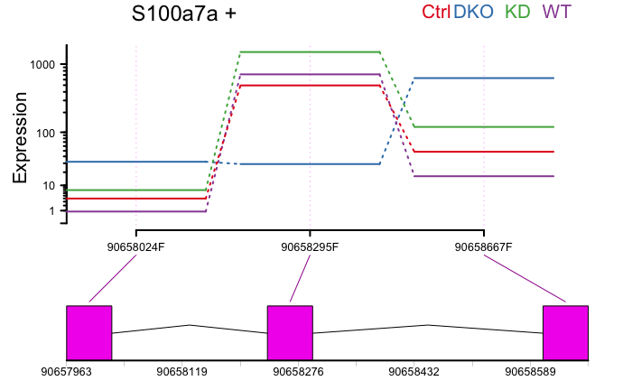

```r
plotDEXSeq(dxr, "S100a7a", legend = TRUE, expression = TRUE, splicing = FALSE, cex.axis = 1.2, cex = 1.3, lwd = 2)
```

To display differential ployA usage use `splicing = TRUE`:

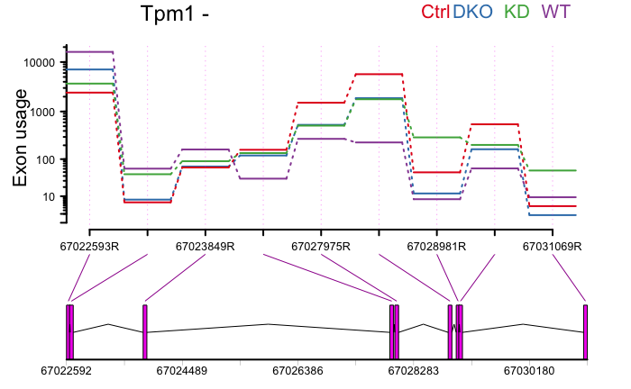

```r
plotDEXSeq(dxr, "Tpm1", legend = TRUE, expression = FALSE, splicing = TRUE, cex.axis = 1.2, cex = 1.3, lwd = 2)
```

To display both experssion and differential ployA usage use `splicing = TRUE` and `expression = TRUE`:

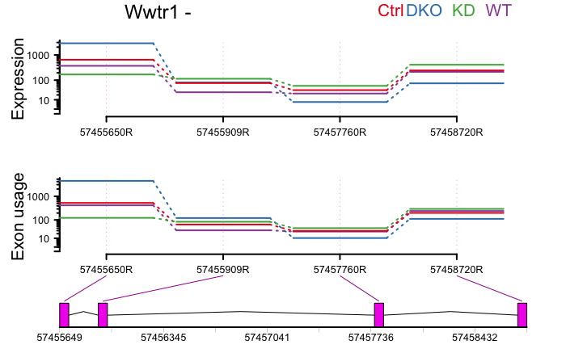

```r
plotDEXSeq(dxr, "Wwtr1", legend = TRUE, expression = TRUE, splicing = TRUE, cex.axis = 1.2, cex = 1.3, lwd = 2)
```

Generate plots for all the top 300 significant genes using `perGeneQValue` function:

```r
dxr %<>% .[!is.na(.$padj), ]
dgene <- data.frame(perGeneQValue=perGeneQValue(dxr)) %>% rownames_to_column("groupID")

dePAS <- dxr %>% data.frame() %>%
  dplyr::select(-matches("dispersion|stat|countData|genomicData")) %>%
  inner_join(dgene) %>% arrange(perGeneQValue) %>% distinct()
# Save the significant differential pA sites (order by perGeneQValue)
"openxlsx" %>% lapply(library, character.only = TRUE) %>% invisible
dePAS_sig <- dePAS %>% filter(padj < 0.1) %T>%
  write.xlsx(file = "3PSeq_DEXSeq_significant_genes.xlsx", sheetName = "dePAS_sig", firstRow = TRUE, headerStyle = createStyle(textDecoration = "BOLD", halign = "center"))
```

```r
DT::datatable(dePAS_sig[1:300, ])
```

|  | groupID | featureID | exonBaseMean | pvalue | padj | DKO | WT | Ctrl | KD | log2fold_WT_DKO | log2fold_Ctrl_DKO | log2fold_KD_DKO | perGeneQValue |
| --- | --- | --- | --- | --- | --- | --- | --- | --- | --- | --- | --- | --- | --- |
| 1 | Cited2 | 17724870F | 462.350526300975 | 1.47711884307745e-32 | 5.00524734505046e-31 | 15.5997877453686 | 14.6292578830484 | 17.3880822466489 | 22.1513196681529 | -0.338463179012281 | 0.612939869384992 | 2.20647398737477 | 0 |
| 2 | Cited2 | 17724976F | 107.982919447176 | 1.51613477917211e-08 | 5.04100582521731e-08 | 12.7920026011246 | 13.3843103956054 | 13.7645835448404 | 11.7298924003981 | 0.214566737310514 | 0.35083625183514 | -0.3931567555497 | 0 |
| 3 | Cited2 | 17725673F | 234.161161192557 | 1.24685182404573e-20 | 1.52171218884768e-19 | 18.0423332756386 | 18.1053350667888 | 9.40064758223516 | 6.72836022486052 | 0.0212784981707692 | -3.13947480788365 | -4.35613172394002 | 0 |
| 4 | Perp | 18856034F | 49.0040296575355 | 9.95705818402593e-19 | 1.01973480230082e-17 | 6.92212827796734 | 10.2418240264564 | 10.527065533889 | 11.7892225983652 | 1.46063793471802 | 1.57343526663211 | 2.05767809696052 | 0 |
| 5 | Perp | 18857070F | 549.721317305098 | 3.52321892092001e-19 | 3.72306419463648e-18 | 19.9114802742492 | 17.6237190179505 | 17.4486050141269 | 16.6999933446836 | -0.769187873243597 | -0.828588178945848 | -1.0835957369042 | 0 |
| 6 | Stx7 | 24188127F | 72.3964013869929 | 9.64272417199509e-09 | 3.30369629034333e-08 | 10.5556128670092 | 7.69299969024442 | 13.8197864428279 | 13.0610897705159 | -1.2135327623473 | 1.21442874877328 | 0.941748067588479 | 0 |
| 7 | Stx7 | 24188284F | 109.001686193311 | 2.00162410809436e-07 | 5.79692945716597e-07 | 10.719278284558 | 13.7419187628629 | 14.525058806788 | 13.8242918547014 | 1.12261367549896 | 1.4001966797938 | 1.15200488077401 | 0 |
| 8 | Stx7 | 24188343F | 34.6131476468685 | 1.07144459197692e-18 | 1.09308744356601e-17 | 1.84908440867034 | 2.30953439733234 | 3.21817493348912 | 13.4804314327669 | 0.653339400199575 | 1.64137095273904 | 6.75492232247124 | 0 |
| 9 | Stx7 | 24188959F | 188.660496432757 | 2.12971735965627e-33 | 7.77171310118524e-32 | 17.4179987121709 | 16.3892337443458 | 13.0291660638433 | 12.7153953277454 | -0.351036065817433 | -1.53225873175187 | -1.64650826740826 | 0 |
| 10 | Ccn2 | 24597658F | 31.5205283446051 | 2.16492926025889e-19 | 2.32096492042122e-18 | 6.47193521216954 | 5.97243227155286 | 7.91045912071009 | 11.7894026893319 | -0.268855259272279 | 0.701293849583696 | 2.28759417481967 | 0 |

[output cut: 290 more lines]

```r
pdf(file= "3PSeq_DEXSeq_significant_genes.top300.pdf")
sig_genes <- dePAS_sig %>% filter(perGeneQValue <= 0.01) %$% groupID %>% unique %>% .[1:300]

for (geneid in sig_genes) {
  nn <- dxr %>% .[.$groupID %in% geneid, ] %>% nrow
  if (nn > 1) {
    plotDEXSeq(dxr, geneid, legend = TRUE, expression = FALSE, splicing = TRUE, cex.axis = 1.2, cex = 1.3, lwd = 2)
  }
}
dev.off()
```

Use EnhancedVolcano package to visualise differentially ployA site usage. Here is an example of the contrast pair “WT vs DKO”:

```r
"EnhancedVolcano" %>% lapply(library, character.only = TRUE) %>% invisible
```

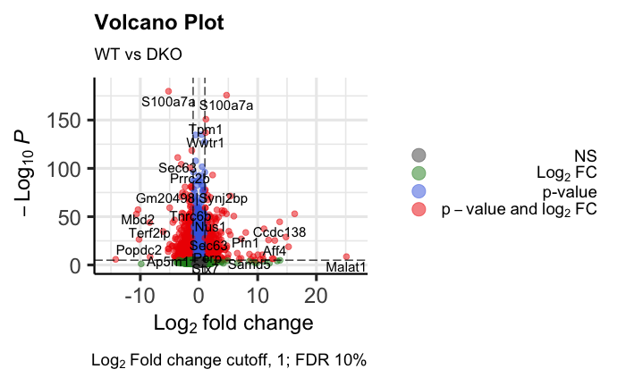

```r
EnhancedVolcano(dePAS_sig, lab = dePAS_sig$groupID, x = 'log2fold_WT_DKO', y = 'pvalue', title = 'Volcano Plot',
                subtitle = 'WT vs DKO', FCcutoff = 1, labSize = 4, legendPosition = "right",
                caption = bquote(~Log[2]~ "Fold change cutoff, 1; FDR 10%"))
```

```r
# It has to be noted that the p-value of each pA site visualized here is calculated based on its change across all the conditions, rather than just the specific contrast pair.
```

NOTE: EnhancedVolcano package was used to generate the above plot, you will need to install it if not already installed.

### 4.1.8 Develop differential pA site testing in each contrast pair

As described in step 4.1.7, the p-values generated in the standard DEXSeq pipeline were calculated based on the pA site usage change across all the conditions, rather than in each contrast pair. Therefore, if we are interested in the pA site usage change in contrast pairs, the DEXSeqDataSet object is supposed to include only the two conditions we are interested. Here we perform the analysis of the contrast pair “KD - Ctrl” as an example.

```r
countData2 <- dplyr::select(countData, DKOsiRNA_1, DKOsiRNA_2, DKONTsiRNA_1, DKONTsiRNA_2)
sampleTable2 <- data.frame(row.names = c("DKOsiRNA_1", "DKOsiRNA_2", "DKONTsiRNA_1", "DKONTsiRNA_2"),
                          condition = c(rep("KD", 2), rep("Ctrl", 2)),
                          libType = rep("single-end", 4))
dxd2 <- DEXSeqDataSet(countData = countData2,
                     sampleData = sampleTable2,
                     design = ~ sample + exon + condition:exon,
                     featureID = new.featureID,
                     groupID = anno$Symbol,
                     featureRanges = PASinfo)
```

```
some variables in design formula are characters, converting to factors
```

```r
dxd2$condition <- factor(dxd2$condition, levels = c("Ctrl", "KD"))
dxd2 %<>% estimateSizeFactors %>% estimateDispersions %>% testForDEU %>% estimateExonFoldChanges(fitExpToVar = "condition")
dxr2 <- DEXSeqResults(dxd2)

mcols(dxr2)$description
```

```
 [1] "group/gene identifier"
 [2] "feature/exon identifier"
 [3] "mean of the counts across samples in each feature/exon"
 [4] "exon dispersion estimate"
 [5] "LRT statistic: full vs reduced"
 [6] "LRT p-value: full vs reduced"
 [7] "BH adjusted p-values"
 [8] "exon usage coefficient"
 [9] "exon usage coefficient"
[10] "relative exon usage fold change"
[11] "GRanges object of the coordinates of the exon/feature"
[12] "matrix of integer counts, of each column containing a sample"
```

```r
## ----tallyPASs------------------------------------------------------------
table(dxr2$padj < 0.1) # Check the number of differential pA sites (FDR < 0.1)
```

```
FALSE  TRUE
 8523  4736
```

```r
## ----tallyGenes------------------------------------------------------------
table(tapply(dxr2$padj < 0.1, dxr2$groupID, any)) # Check the number of gene overlapped with differential pA site clusters (FDR < 0.1)
```

```
FALSE  TRUE
 2256  2320
```

```r
# Selection and visualization of the results
topdiff.PAS2 <- dxr2 %>% as.data.frame %>% rownames_to_column %>% arrange(padj) %$% groupID[1:100]
head(topdiff.PAS2)
```

```
[1] "Ankrd1" "Ankrd1" "Hmgb2"  "Calm3"  "Calm3"  "Gsn"
```

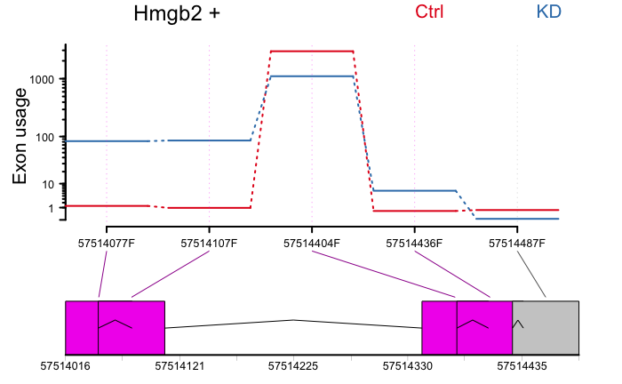

```r
plotDEXSeq(dxr2, "Hmgb2", legend = TRUE, expression = FALSE, splicing = TRUE, cex.axis = 1.2, cex = 1.3, lwd = 2)
```

```r
dxr2 %<>% .[!is.na(.$padj), ]
dgene2 <- data.frame(perGeneQValue=perGeneQValue(dxr2)) %>% rownames_to_column("groupID")

dePAS2 <- dxr2 %>% data.frame() %>%
  dplyr::select(-matches("dispersion|stat|countData|genomicData")) %>%
  inner_join(dgene2) %>% arrange(perGeneQValue) %>% distinct()
# Save the significant differential pA sites (order by perGeneQValue)
add.xlsx.sheet <- function(fileName, sheetName, data){
  wb <- loadWorkbook(fileName)
  addWorksheet(wb, sheetName = sheetName)
  freezePane(wb, sheet = sheetName, firstRow = TRUE)
  writeData(wb, sheet = sheetName, data, headerStyle = createStyle(textDecoration = "BOLD", halign = "center"))
  saveWorkbook(wb, file = fileName, overwrite = TRUE)
}
dePAS_sig2 <- dePAS2 %>% filter(padj < 0.1) %T>%
  add.xlsx.sheet(file = "3PSeq_DEXSeq_significant_genes.xlsx", "KD vs Ctrl", .)
DT::renderDataTable(dePAS_sig2[1:300, ])
```

```
<shiny.render.function>
```

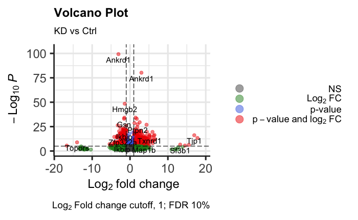

```r
EnhancedVolcano(dePAS_sig2, lab = dePAS_sig2$groupID, x = 'log2fold_KD_Ctrl', y = 'pvalue', title = 'Volcano Plot',
                subtitle = 'KD vs Ctrl', FCcutoff = 1, labSize = 4, legendPosition = "right",
                caption = bquote(~Log[2]~ "Fold change cutoff, 1; FDR 10%"))
```

## 4.2 Using diffSplice package

### 4.2.1 Load required libraries

```r
c("limma", "edgeR") %>% lapply(library, character.only = TRUE) %>% invisible
```

### 4.2.2 Creat the DGEList object and preprocessing

```r
fit <- {
  dge <- DGEList(counts = countData) %>% calcNormFactors
  Treat <- factor(sampleTable$condition)
  design <- model.matrix(~0 + Treat)
  colnames(design) <- levels(Treat)
  voomWithQualityWeights(dge, design, plot = FALSE)
} %>% lmFit(design) %>% eBayes
```

### 4.2.3 Make contrasts for differential PAS usage

In diffSplice pipeline, the differential pA site usage analysis can be performed in contrast pairs, which could be defined using `makeContrasts` function.

```r
contrast.matrix <- makeContrasts(DKO_vs_WT = DKO-WT, Ctrl_vs_DKO = Ctrl-DKO,
                                 KD_vs_Ctrl = KD-Ctrl, KD_vs_DKO = KD-DKO,
                                 levels = design)
fit2 <- fit %>% contrasts.fit(contrast.matrix) %>% eBayes
summary(decideTests(fit2))
```

```
       DKO_vs_WT Ctrl_vs_DKO KD_vs_Ctrl KD_vs_DKO
Down        4107        3092       1659      4463
NotSig      4953        6621      10293      4217
Up          4223        3570       1331      4603
```

### 4.2.4 Differential pA site usage analysis

```r
ex <- diffSplice(fit2, geneid = anno$Symbol, exonid = new.featureID)
```

```
Total number of exons:  13283
Total number of genes:  4588
Number of genes with 1 exon:  0
Mean number of exons in a gene:  3
Max number of exons in a gene:  27
```

```r
#Check the top significant results with topSplice
topSplice(ex)
```

|  | GeneID | NExons | P.Value | FDR |
| --- | --- | --- | --- | --- |
| 6056 | Gm10925 | 13 | 2.173787e-23 | 7.104740e-20 |
| 11488 | Kcnq1ot1 | 6 | 3.097097e-23 | 7.104740e-20 |
| 8638 | Gm11410 | 7 | 4.200706e-22 | 6.424279e-19 |
| 6028 | Gm28439 | 10 | 9.438225e-22 | 1.082564e-18 |
| 888 | Ppp2ca | 6 | 1.266296e-20 | 1.161953e-17 |
| 1871 | Pnn | 10 | 3.787058e-20 | 2.895837e-17 |
| 5107 | Lox | 10 | 8.806594e-19 | 5.772093e-16 |
| 4442 | Qk | 10 | 3.505834e-18 | 2.010596e-15 |
| 5503 | Ankrd1 | 3 | 5.892101e-18 | 3.003662e-15 |
| 7236 | Gm13341 | 8 | 7.786275e-18 | 3.572343e-15 |

NOTE: This step uses the exon information object created in 4.1.2. Make sure it is loaded in the current working environment.

### 4.2.5 Visualization of the contrast DKO-WT

```r
sig1 <-topSplice(ex, n = Inf, FDR = 0.1, coef = 1, test= "t", sort.by = "logFC") #Save the results sorted by logFC with FDR < 0.1
DT::datatable(sig1[1:300, ])
```

|  | ExonID | GeneID | logFC | t | P.Value | FDR |
| --- | --- | --- | --- | --- | --- | --- |
| 11808 | 112020502F | Terf2ip | 10.7050654512404 | 12.4489499572311 | 4.399960310705e-11 | 4.05865783382601e-09 |
| 11809 | 112020532F | Terf2ip | -10.7050654512404 | -12.4489499572311 | 4.399960310705e-11 | 4.05865783382601e-09 |
| 7901 | 90658295F | S100a7a | -9.93317016148372 | -22.632887888793 | 4.82314791882272e-18 | 9.15226768653174e-15 |
| 297 | 100574551F | Cep290 | -9.81409223092654 | -15.7822179766411 | 1.08824600139733e-15 | 6.28485723328728e-13 |
| 4520 | 29261118R | Ppil1 | 9.53468366660846 | 9.33962602589575 | 7.1247282826423e-09 | 2.39589280451489e-07 |
| 4519 | 29250830R | Ppil1 | -9.53468366660846 | -9.33962602589575 | 7.12472828264234e-09 | 2.39589280451489e-07 |
| 119 | 58501299F | Ccdc138 | 9.53389974329875 | 17.153879372197 | 1.01157430244906e-13 | 2.92103075205021e-11 |
| 118 | 58500810F | Ccdc138 | -9.53389974329874 | -17.1538793721969 | 1.01157430244907e-13 | 2.92103075205021e-11 |
| 7902 | 90658667F | S100a7a | 8.79110911804216 | 19.177158714921 | 2.34350811545616e-16 | 1.94555114360026e-13 |
| 956 | 67688990F | Gas7 | 8.11604968262125 | 5.5835670940843 | 1.60587721818071e-05 | 0.000132243441345904 |

[output cut: 290 more lines]

```r
pdf(file = "3PSeq_diffSplice_plotSplice_DKO_WT.pdf")
plotSplice(ex, coef = 1, geneid = "Terf2ip")
plotSplice(ex, coef = 1, geneid = "S100a7a")
```

```r
plotSplice(ex, coef = 1, geneid = "Cep290")
dev.off()
```

```r
pdf(file = "3PSeq_diffSplice_Volcano_DKO_WT.pdf", height = 10, width = 12)
```

```r
EnhancedVolcano(sig1, lab = sig1$GeneID, xlab = bquote(~Log[2]~ 'fold change'),
                x = 'logFC', y = 'P.Value', title = 'Volcano Plot', subtitle = 'DKO vs WT',
                # pCutoff = 10e-16,
                FCcutoff = 1, labSize = 8, legendPosition = "right")
dev.off()
```

```r
#Save the list of top differentially spliced exons at FDR 10%
write.xlsx(sig1, file = "3PSeq_diffSplice_significant_genes.xlsx", sheetName = "DKO vs WT", firstRow = TRUE, headerStyle = createStyle(textDecoration = "BOLD", halign = "center"))
```

### 4.2.6 Visualization of the contrast Ctrl-DKO

```r
sig2 <-topSplice(ex, n = Inf, FDR = 0.1, coef = 2, test= "t", sort.by = "logFC")
DT::datatable(sig2[1:300, ])
```

|  | ExonID | GeneID | logFC | t | P.Value | FDR |
| --- | --- | --- | --- | --- | --- | --- |
| 4519 | 29250830R | Ppil1 | 10.5202031056558 | 6.76074681770228 | 1.17198235580037e-06 | 3.75119075472203e-05 |
| 4520 | 29261118R | Ppil1 | -10.5202031056558 | -6.76074681770228 | 1.17198235580038e-06 | 3.75119075472203e-05 |
| 1300 | 18326986R | Gm12020 | -10.0906853538267 | -10.1353196775055 | 1.75130223977119e-09 | 2.40057334745517e-07 |
| 1299 | 18326509R | Gm12020 | 10.0906853538267 | 10.1353196775055 | 1.75130223977119e-09 | 2.40057334745517e-07 |
| 118 | 58500810F | Ccdc138 | 9.74817270357426 | 14.038148977313 | 4.69726481156947e-12 | 2.49575073968313e-09 |
| 119 | 58501299F | Ccdc138 | -9.74817270357426 | -14.0381489773129 | 4.69726481156953e-12 | 2.49575073968313e-09 |
| 297 | 100574551F | Cep290 | 9.61829851524838 | 12.6303879478391 | 2.98841460408761e-13 | 3.30792593217465e-10 |
| 11809 | 112020532F | Terf2ip | 9.37565228248083 | 7.57910751479755 | 2.1093537521412e-07 | 9.66156754816952e-06 |
| 11808 | 112020502F | Terf2ip | -9.37565228248082 | -7.57910751479755 | 2.1093537521412e-07 | 9.66156754816952e-06 |
| 1779 | 4849345F | Wdcp | -8.40916405903285 | -9.92675348489484 | 2.51153392394463e-09 | 3.04847144298971e-07 |

[output cut: 290 more lines]

```r
pdf(file = "3PSeq_diffSplice_plotSplice_Ctrl_DKO.pdf")
plotSplice(ex, coef = 2, geneid = "Ppil1")
plotSplice(ex, coef = 2, geneid = "Ccdc138")
```

```r
plotSplice(ex, coef = 2, geneid = "Cep290")
dev.off()
```

```r
pdf(file = "3PSeq_diffSplice_Volcano_Ctrl_DKO.pdf", height = 10, width = 12)
```

```r
EnhancedVolcano(sig2, lab = sig2$GeneID, xlab = bquote(~Log[2]~ 'fold change'),
                x = 'logFC', y = 'P.Value', title = 'Volcano Plot', subtitle = 'Ctrl vs DKO',
                # pCutoff = 10e-16,
                FCcutoff = 1, labSize = 8, legendPosition = "right")
dev.off()
```

```r
#Save the list of top differentially spliced exons at FDR 10%
add.xlsx.sheet(file = "3PSeq_diffSplice_significant_genes.xlsx", "Ctrl vs DKO", sig2)
```

### 4.2.7 Visualization of the contrast KD-Ctrl

```r
sig3 <-topSplice(ex, n = Inf, FDR = 0.1, coef = 3, test= "t", sort.by = "logFC")
DT::datatable(sig3[1:300, ])
```

|  | ExonID | GeneID | logFC | t | P.Value | FDR |
| --- | --- | --- | --- | --- | --- | --- |
| 8368 | 113605467R | Amy1\|Rnpc3 | -8.99816685476474 | -5.59931569918355 | 1.54896726306283e-05 | 0.000617865830488397 |
| 8369 | 113605566R | Amy1\|Rnpc3 | 8.99816685476474 | 5.59931569918354 | 1.54896726306283e-05 | 0.000617865830488397 |
| 2008 | 109560224F | Meg3 | 8.74550078693116 | 6.95024405051091 | 1.24523211607539e-08 | 4.59456061050818e-06 |
| 11279 | 65342641R | Tjp1 | 7.69385297215899 | 7.6412913619731 | 1.85845482098811e-07 | 2.87044830083548e-05 |
| 11278 | 65296150R | Tjp1 | -7.69385297215899 | -7.6412913619731 | 1.85845482098812e-07 | 2.87044830083548e-05 |
| 3140 | 60219470R | Nupl1\|Gm49336 | -7.20381671506791 | -5.10573626091057 | 4.85433887300464e-05 | 0.00137196494735777 |
| 3139 | 60218078R | Nupl1\|Gm49336 | 7.20381671506791 | 5.10573626091057 | 4.85433887300464e-05 | 0.00137196494735777 |
| 8091 | 144597674F | Selenof | -6.90947419765132 | -6.57696271971395 | 1.74374230868746e-06 | 0.000144763306789347 |
| 8090 | 144597634F | Selenof | 6.90947419765131 | 6.57696271971395 | 1.74374230868746e-06 | 0.000144763306789347 |
| 7903 | 92689729F | Gm4202 | 6.55035256062413 | 5.86083025083969 | 8.54134957294641e-06 | 0.00043636440914403 |

[output cut: 290 more lines]

```r
pdf(file = "3PSeq_diffSplice_plotSplice_KD_Ctrl.pdf")
plotSplice(ex, coef = 3, geneid = "Amy1|Rnpc3")
plotSplice(ex, coef = 3, geneid = "Meg3")
```

```r
plotSplice(ex, coef = 3, geneid = "Tjp1")
dev.off()
```

```r
pdf(file = "3PSeq_diffSplice_Volcano_KD_Ctrl.pdf", height = 10, width = 12)
```

```r
EnhancedVolcano(sig3, lab = sig3$GeneID, xlab = bquote(~Log[2]~ 'fold change'),
                x = 'logFC', y = 'P.Value', title = 'Volcano Plot', subtitle = 'KD vs Ctrl',
                # pCutoff = 10e-16,
                FCcutoff = 1, labSize = 8, legendPosition = "right")
dev.off()
```

```r
#Save the list of top differentially spliced exons at FDR 10%
add.xlsx.sheet(file = "3PSeq_diffSplice_significant_genes.xlsx", "KD vs Ctrl", sig3)
```

### 4.2.8 Visualization of the contrast KD-DKO

```r
sig4 <-topSplice(ex, n = Inf, FDR = 0.1, coef = 4, test= "t", sort.by = "logFC")
DT::datatable(sig4[1:300, ])
```

|  | ExonID | GeneID | logFC | t | P.Value | FDR |
| --- | --- | --- | --- | --- | --- | --- |
| 118 | 58500810F | Ccdc138 | 11.4646025383081 | 16.1557895758221 | 3.22606836238511e-13 | 3.2694529481309e-11 |
| 119 | 58501299F | Ccdc138 | -11.4646025383081 | -16.1557895758221 | 3.22606836238511e-13 | 3.2694529481309e-11 |
| 956 | 67688990F | Gas7 | -11.29616817401 | -6.32854929184009 | 3.00419884152463e-06 | 1.74485234857768e-05 |
| 955 | 67687100F | Gas7 | 11.29616817401 | 6.32854929184009 | 3.00419884152463e-06 | 1.74485234857768e-05 |
| 11809 | 112020532F | Terf2ip | 10.5240506328166 | 8.76257985159048 | 2.06921426465153e-08 | 2.76365990454183e-07 |
| 11808 | 112020502F | Terf2ip | -10.5240506328166 | -8.76257985159048 | 2.06921426465154e-08 | 2.76365990454183e-07 |
| 4519 | 29250830R | Ppil1 | 10.1535560315354 | 7.32076697154405 | 3.58964956218249e-07 | 2.92702978112156e-06 |
| 4520 | 29261118R | Ppil1 | -10.1535560315354 | -7.32076697154405 | 3.58964956218251e-07 | 2.92702978112156e-06 |
| 8368 | 113605467R | Amy1\|Rnpc3 | -10.1444102554522 | -8.49560556264713 | 3.43775577633295e-08 | 4.12872603770624e-07 |
| 8369 | 113605566R | Amy1\|Rnpc3 | 10.1444102554522 | 8.49560556264712 | 3.43775577633298e-08 | 4.12872603770624e-07 |

[output cut: 290 more lines]

```r
pdf(file = "3PSeq_diffSplice_plotSplice_KD_DKO.pdf")
plotSplice(ex, coef = 4, geneid = "Ccdc138")
plotSplice(ex, coef = 4, geneid = "Gas7")
```

```r
plotSplice(ex, coef = 4, geneid = "Terf2ip")
plotSplice(ex, coef = 4, geneid = "Amy1|Rnpc3")
```

```r
plotSplice(ex, coef = 4, geneid = "Ppil1")
plotSplice(ex, coef = 4, geneid = "Ankrd10")
```

```r
plotSplice(ex, coef = 4, geneid = "Wdcp")
dev.off()
```

```r
pdf(file = "3PSeq_diffSplice_Volcano_KD_DKO.pdf", height = 10, width = 12)
```

```r
EnhancedVolcano(sig4, lab = sig4$GeneID, xlab = bquote(~Log[2]~ 'fold change'),
                x = 'logFC', y = 'P.Value', title = 'Volcano Plot', subtitle = 'KD vs DKO',
                # pCutoff = 10e-16,
                FCcutoff = 1, labSize = 8, legendPosition = "right")
dev.off()
```

```r
#Save the list of top differentially spliced exons at FDR 10%
add.xlsx.sheet(file = "3PSeq_diffSplice_significant_genes.xlsx", "KD vs DKO", sig4)
```